# Regression Models

Justin Sarna

April 20, 2017

```r
acs <- read.table("http://jaredlander.com/data/acs_ny.csv",sep=",",
                  header=TRUE, stringsAsFactors=TRUE)
```

```r
# Load the necessary libraries
library(ggplot2)
library(useful)
library(caret)
library(ISLR)
library(scales)
library(plyr)
library(rpart)
library(rpart.plot)
library(class)
library(MuMIn)
library(caret)
library(dplyr)
library(RColorBrewer)
library(randomForest)
library(kernlab)
library(nlme)
library(lme4)
library(mgcv)
```

# Create new variables based on EDA

```r
# code from hw4 to be used for creating additional models
acs$HighIncome <- as.numeric(with(acs, FamilyIncome >= 250000))
acs$foodstamp_binary <- ifelse(acs$FoodStamp == "Yes",1,0) # (yes = 1, no = 0)
acs$own_home <- ifelse(acs$OwnRent == "Rented",0, ifelse(acs$FamilyIncome == "Mortgage",1,2)) # (own = 1, rent = 0)
acs$family_type_cat <- ifelse(acs$FamilyType == "Married",1, ifelse(acs$FamilyIncome == "Female Head",2,3))

# married = 1, male head = 2, female head = 3
acs$InsuranceHigh <- (acs$Insurance > 1000) * 1
acs$NumWorkers2 <- (acs$NumWorkers == 2) * 1
acs$HouseCostsHigh <- (acs$HouseCosts > 1000) * 1
acs$high_electric <- (acs$ElectricBill > 350) * 1

# Create binary variable where 1 = not on food stamps & not renting & married
acs$HI_pred1[acs$FoodStamp == 'No' & acs$OwnRent != 'Rented' & acs$FamilyType == 'Married'] <- 1

# Break it into a training and test set with an 80/20 split.
set.seed(447)
testrecs <- sample(nrow(acs),0.2 * nrow(acs))
acs_test <- acs[testrecs,]
acs_fit <- acs[-testrecs,]
```

Let’s start by building a *null* model in which you simply predict that everyone’s income is < 250000 (since the majority of incomes are less than 250000).

## Null Model for model comparison

```r
acs$null_model <- 0
```

Create a confusion matrix table and compute the overall accuracy of this model as well as its sensitivity and specificity.

```r
table(acs$HighIncome, acs$null_model)
```

```
##
##         0
##   0 21356
##   1  1389
```

```r
prop.table(table(acs$HighIncome, acs$null_model))
```

```
##
##              0
##   0 0.93893163
##   1 0.06106837
```

```r
confusionMatrix(as.factor(acs$null_model), as.factor(acs$HighIncome), positive = "1")
```

```
## Confusion Matrix and Statistics
##
##           Reference
## Prediction     0     1
##          0 21356  1389
##          1     0     0
##
##                Accuracy : 0.9389
##                  95% CI : (0.9357, 0.942)
##     No Information Rate : 0.9389
##     P-Value [Acc > NIR] : 0.5071
##
##                   Kappa : 0
##  Mcnemar's Test P-Value : <2e-16
##
##             Sensitivity : 0.00000
##             Specificity : 1.00000
##          Pos Pred Value :     NaN
##          Neg Pred Value : 0.93893
##              Prevalence : 0.06107
##          Detection Rate : 0.00000
##    Detection Prevalence : 0.00000
##       Balanced Accuracy : 0.50000
##
##        'Positive' Class : 1
##
```

# Logistic Regression

#### logistic regression model 1

```r
logmod1 <- glm(HighIncome ~ FamilyType + NumVehicles + OwnRent + Insurance + YearBuilt, data=acs_fit,
               family=binomial(link="logit"))

summary(logmod1)
```

```
##
## Call:
## glm(formula = HighIncome ~ FamilyType + NumVehicles + OwnRent +
##     Insurance + YearBuilt, family = binomial(link = "logit"),
##     data = acs_fit)
##
## Deviance Residuals:
##     Min       1Q   Median       3Q      Max
## -1.9844  -0.3540  -0.2875  -0.1979   3.3452
##
## Coefficients:
##                        Estimate Std. Error z value Pr(>|z|)
## (Intercept)          -1.606e+01  1.539e+02  -0.104    0.917
## FamilyTypeMale Head   6.722e-01  3.116e-01   2.157    0.031 *
## FamilyTypeMarried     1.674e+00  2.035e-01   8.225  < 2e-16 ***
## NumVehicles           2.463e-01  3.374e-02   7.300 2.88e-13 ***
## OwnRentOutright       7.038e-01  3.182e-01   2.212    0.027 *
## OwnRentRented        -1.159e-01  1.937e-01  -0.598    0.550
## Insurance             6.605e-04  2.212e-05  29.855  < 2e-16 ***
## YearBuilt1940-1949    9.780e+00  1.539e+02   0.064    0.949
## YearBuilt1950-1959    1.034e+01  1.539e+02   0.067    0.946
## YearBuilt1960-1969    1.036e+01  1.539e+02   0.067    0.946
## YearBuilt1970-1979    1.015e+01  1.539e+02   0.066    0.947
## YearBuilt1980-1989    1.049e+01  1.539e+02   0.068    0.946
## YearBuilt1990-1999    1.050e+01  1.539e+02   0.068    0.946
## YearBuilt2000-2004    1.061e+01  1.539e+02   0.069    0.945
## YearBuilt2005         1.071e+01  1.539e+02   0.070    0.945
## YearBuilt2006         1.105e+01  1.539e+02   0.072    0.943
## YearBuilt2007         1.074e+01  1.539e+02   0.070    0.944
## YearBuilt2008         1.080e+01  1.539e+02   0.070    0.944
## YearBuilt2009         1.046e+01  1.539e+02   0.068    0.946
## YearBuilt2010         1.135e+01  1.539e+02   0.074    0.941
## YearBuiltBefore 1939  1.033e+01  1.539e+02   0.067    0.946
## ---
## Signif. codes:  0 '***' 0.001 '**' 0.01 '*' 0.05 '.' 0.1 ' ' 1
##
## (Dispersion parameter for binomial family taken to be 1)
##
##     Null deviance: 8398.1  on 18195  degrees of freedom
## Residual deviance: 7076.0  on 18175  degrees of freedom
## AIC: 7118
##
## Number of Fisher Scoring iterations: 12
```

```r
acs_test$yhat_logmod1 <- predict(logmod1, newdata=acs_test, type='response')

acs_test$yhat_logmod1 <- (acs_test$yhat_logmod1 > 0.05) * 1

log_mod1_aic <- summary(logmod1)$aic

log_cm1 <- confusionMatrix(as.factor(acs_test$yhat_logmod1), as.factor(acs_test$HighIncome), positive = "1")

log_cm1
```

```
## Confusion Matrix and Statistics
##
##           Reference
## Prediction    0    1
##          0 2662   57
##          1 1615  215
##
##                Accuracy : 0.6324
##                  95% CI : (0.6182, 0.6465)
##     No Information Rate : 0.9402
##     P-Value [Acc > NIR] : 1
##
##                   Kappa : 0.1121
##  Mcnemar's Test P-Value : <2e-16
##
##             Sensitivity : 0.79044
##             Specificity : 0.62240
##          Pos Pred Value : 0.11749
##          Neg Pred Value : 0.97904
##              Prevalence : 0.05979
##          Detection Rate : 0.04726
##    Detection Prevalence : 0.40229
##       Balanced Accuracy : 0.70642
##
##        'Positive' Class : 1
##
```

#### logistic regression model 2

```r
logmod2 <- glm(HighIncome ~ FamilyType + FoodStamp + OwnRent, data=acs_fit, family=binomial(link="logit"))

summary(logmod2)
```

```
##
## Call:
## glm(formula = HighIncome ~ FamilyType + FoodStamp + OwnRent,
##     family = binomial(link = "logit"), data = acs_fit)
##
## Deviance Residuals:
##     Min       1Q   Median       3Q      Max
## -0.4992  -0.4048  -0.4048  -0.1728   3.7799
##
## Coefficients:
##                     Estimate Std. Error z value Pr(>|z|)
## (Intercept)          -4.1971     0.1947 -21.557  < 2e-16 ***
## FamilyTypeMale Head   0.6399     0.3026   2.114   0.0345 *
## FamilyTypeMarried     1.7363     0.1968   8.821  < 2e-16 ***
## FoodStampYes         -1.9012     0.3578  -5.314 1.08e-07 ***
## OwnRentOutright       0.4413     0.2964   1.489   0.1365
## OwnRentRented        -1.0447     0.1885  -5.541 3.00e-08 ***
## ---
## Signif. codes:  0 '***' 0.001 '**' 0.01 '*' 0.05 '.' 0.1 ' ' 1
##
## (Dispersion parameter for binomial family taken to be 1)
##
##     Null deviance: 8398.1  on 18195  degrees of freedom
## Residual deviance: 8037.1  on 18190  degrees of freedom
## AIC: 8049.1
##
## Number of Fisher Scoring iterations: 7
```

```r
acs_test$yhat_logmod2 <- predict(logmod2, newdata=acs_test, type='response')

acs_test$yhat_logmod2 <- (acs_test$yhat_logmod2 > 0.05) * 1

log_mod2_aic <- summary(logmod2)$aic

log_cm2 <- confusionMatrix(as.factor(acs_test$yhat_logmod2), as.factor(acs_test$HighIncome), positive = "1")

log_cm2
```

```
## Confusion Matrix and Statistics
##
##           Reference
## Prediction    0    1
##          0 1265   28
##          1 3012  244
##
##                Accuracy : 0.3317
##                  95% CI : (0.318, 0.3456)
##     No Information Rate : 0.9402
##     P-Value [Acc > NIR] : 1
##
##                   Kappa : 0.0314
##  Mcnemar's Test P-Value : <2e-16
##
##             Sensitivity : 0.89706
##             Specificity : 0.29577
##          Pos Pred Value : 0.07494
##          Neg Pred Value : 0.97834
##              Prevalence : 0.05979
##          Detection Rate : 0.05364
##    Detection Prevalence : 0.71576
##       Balanced Accuracy : 0.59641
##
##        'Positive' Class : 1
##
```

#### logistic regression model 3

```r
logmod3 <- glm(HighIncome ~ InsuranceHigh + NumWorkers2 + HouseCostsHigh + FoodStamp + OwnRent,
               data=acs_fit, family=binomial(link="logit"))

summary(logmod3)
```

```
##
## Call:
## glm(formula = HighIncome ~ InsuranceHigh + NumWorkers2 + HouseCostsHigh +
##     FoodStamp + OwnRent, family = binomial(link = "logit"), data = acs_fit)
##
## Deviance Residuals:
##     Min       1Q   Median       3Q      Max
## -1.2253  -0.3183  -0.2682  -0.1640   3.6467
##
## Coefficients:
##                 Estimate Std. Error z value Pr(>|z|)
## (Intercept)     -4.30241    0.09797 -43.915  < 2e-16 ***
## InsuranceHigh    1.34537    0.07504  17.929  < 2e-16 ***
## NumWorkers2      0.07590    0.06409   1.184   0.2363
## HouseCostsHigh   1.26356    0.09694  13.035  < 2e-16 ***
## FoodStampYes    -2.07741    0.35866  -5.792 6.95e-09 ***
## OwnRentOutright  1.72956    0.31359   5.515 3.48e-08 ***
## OwnRentRented   -0.34415    0.19554  -1.760   0.0784 .
## ---
## Signif. codes:  0 '***' 0.001 '**' 0.01 '*' 0.05 '.' 0.1 ' ' 1
##
## (Dispersion parameter for binomial family taken to be 1)
##
##     Null deviance: 8398.1  on 18195  degrees of freedom
## Residual deviance: 7305.5  on 18189  degrees of freedom
## AIC: 7319.5
##
## Number of Fisher Scoring iterations: 7
```

```r
acs_test$yhat_logmod3 <- predict(logmod3, newdata=acs_test, type='response')

acs_test$yhat_logmod3 <- (acs_test$yhat_logmod3 > 0.05) * 1

log_mod3_aic <- summary(logmod3)$aic

log_cm3 <- confusionMatrix(as.factor(acs_test$yhat_logmod3), as.factor(acs_test$HighIncome), positive = "1")

log_cm3
```

```
## Confusion Matrix and Statistics
##
##           Reference
## Prediction    0    1
##          0 3090   72
##          1 1187  200
##
##                Accuracy : 0.7232
##                  95% CI : (0.71, 0.7362)
##     No Information Rate : 0.9402
##     P-Value [Acc > NIR] : 1
##
##                   Kappa : 0.1568
##  Mcnemar's Test P-Value : <2e-16
##
##             Sensitivity : 0.73529
##             Specificity : 0.72247
##          Pos Pred Value : 0.14420
##          Neg Pred Value : 0.97723
##              Prevalence : 0.05979
##          Detection Rate : 0.04397
##    Detection Prevalence : 0.30490
##       Balanced Accuracy : 0.72888
##
##        'Positive' Class : 1
##
```

#### logistic regression model 4

```r
logmod4 <- glm(HighIncome ~ InsuranceHigh + NumWorkers2 + HouseCostsHigh, data=acs_fit, family=binomial(link="logit"))

summary(logmod4)
```

```
##
## Call:
## glm(formula = HighIncome ~ InsuranceHigh + NumWorkers2 + HouseCostsHigh,
##     family = binomial(link = "logit"), data = acs_fit)
##
## Deviance Residuals:
##     Min       1Q   Median       3Q      Max
## -0.5958  -0.3163  -0.2879  -0.1577   2.9642
##
## Coefficients:
##                Estimate Std. Error z value Pr(>|z|)
## (Intercept)    -4.38071    0.09202 -47.604   <2e-16 ***
## InsuranceHigh   1.41041    0.07252  19.447   <2e-16 ***
## NumWorkers2     0.11334    0.06374   1.778   0.0753 .
## HouseCostsHigh  1.21827    0.09407  12.950   <2e-16 ***
## ---
## Signif. codes:  0 '***' 0.001 '**' 0.01 '*' 0.05 '.' 0.1 ' ' 1
##
## (Dispersion parameter for binomial family taken to be 1)
##
##     Null deviance: 8398.1  on 18195  degrees of freedom
## Residual deviance: 7404.8  on 18192  degrees of freedom
## AIC: 7412.8
##
## Number of Fisher Scoring iterations: 6
```

```r
acs_test$yhat_logmod4 <- predict(logmod4, newdata=acs_test, type='response')

acs_test$yhat_logmod4 <- (acs_test$yhat_logmod4 > 0.05) * 1

log_mod4_aic <- summary(logmod4)$aic

log_cm4 <- confusionMatrix(as.factor(acs_test$yhat_logmod4), as.factor(acs_test$HighIncome), positive = "1")

log_cm4
```

```
## Confusion Matrix and Statistics
##
##           Reference
## Prediction    0    1
##          0 3072   73
##          1 1205  199
##
##                Accuracy : 0.7191
##                  95% CI : (0.7058, 0.7321)
##     No Information Rate : 0.9402
##     P-Value [Acc > NIR] : 1
##
##                   Kappa : 0.1526
##  Mcnemar's Test P-Value : <2e-16
##
##             Sensitivity : 0.73162
##             Specificity : 0.71826
##          Pos Pred Value : 0.14174
##          Neg Pred Value : 0.97679
##              Prevalence : 0.05979
##          Detection Rate : 0.04375
##    Detection Prevalence : 0.30864
##       Balanced Accuracy : 0.72494
##
##        'Positive' Class : 1
##
```

#### logistic regression model 5

```r
logmod5 <- glm(HighIncome ~ FamilyType + NumBedrooms + NumChildren + NumPeople + NumRooms + NumUnits + NumVehicles +
                 NumWorkers + OwnRent + HouseCosts + ElectricBill + FoodStamp + Insurance + Language +
                 InsuranceHigh + NumWorkers2 + HouseCostsHigh, data=acs_fit, family=binomial(link="logit"))

summary(logmod5)
```

```
##
## Call:
## glm(formula = HighIncome ~ FamilyType + NumBedrooms + NumChildren +
##     NumPeople + NumRooms + NumUnits + NumVehicles + NumWorkers +
##     OwnRent + HouseCosts + ElectricBill + FoodStamp + Insurance +
##     Language + InsuranceHigh + NumWorkers2 + HouseCostsHigh,
##     family = binomial(link = "logit"), data = acs_fit)
##
## Deviance Residuals:
##     Min       1Q   Median       3Q      Max
## -2.5995  -0.3188  -0.2038  -0.1272   3.6788
##
## Coefficients:
##                           Estimate Std. Error z value Pr(>|z|)
## (Intercept)             -2.020e+01  1.550e+02  -0.130 0.896356
## FamilyTypeMale Head      5.779e-01  3.213e-01   1.798 0.072102 .
## FamilyTypeMarried        1.436e+00  2.069e-01   6.937 4.00e-12 ***
## NumBedrooms              1.191e-01  3.507e-02   3.396 0.000685 ***
## NumChildren              1.853e-01  5.317e-02   3.486 0.000491 ***
## NumPeople               -2.690e-01  5.039e-02  -5.338 9.39e-08 ***
## NumRooms                 1.064e-01  1.426e-02   7.461 8.61e-14 ***
## NumUnitsSingle attached  1.320e+01  1.550e+02   0.085 0.932166
## NumUnitsSingle detached  1.284e+01  1.550e+02   0.083 0.933970
## NumVehicles              2.531e-01  4.244e-02   5.963 2.48e-09 ***
## NumWorkers               1.778e-01  5.742e-02   3.096 0.001964 **
## OwnRentOutright          1.930e+00  3.441e-01   5.609 2.04e-08 ***
## OwnRentRented            3.982e-01  2.026e-01   1.965 0.049373 *
## HouseCosts               4.985e-04  2.945e-05  16.926  < 2e-16 ***
## ElectricBill             2.001e-03  2.980e-04   6.714 1.89e-11 ***
## FoodStampYes            -1.255e+00  3.727e-01  -3.367 0.000760 ***
## Insurance                2.365e-04  3.125e-05   7.568 3.79e-14 ***
## LanguageEnglish         -2.851e-01  1.629e-01  -1.750 0.080110 .
## LanguageOther           -1.487e-01  2.899e-01  -0.513 0.607872
## LanguageOther European  -1.955e-01  1.839e-01  -1.063 0.287918
## LanguageSpanish         -6.078e-01  2.096e-01  -2.899 0.003739 **
## InsuranceHigh            4.681e-01  9.381e-02   4.990 6.05e-07 ***
## NumWorkers2              3.137e-02  7.781e-02   0.403 0.686814
## HouseCostsHigh           1.797e-01  1.155e-01   1.555 0.119832
## ---
## Signif. codes:  0 '***' 0.001 '**' 0.01 '*' 0.05 '.' 0.1 ' ' 1
##
## (Dispersion parameter for binomial family taken to be 1)
##
##     Null deviance: 8398.1  on 18195  degrees of freedom
## Residual deviance: 6140.7  on 18172  degrees of freedom
## AIC: 6188.7
##
## Number of Fisher Scoring iterations: 16
```

```r
acs_test$yhat_logmod5 <- predict(logmod5, newdata=acs_test, type='response')

acs_test$yhat_logmod5 <- (acs_test$yhat_logmod5 > 0.05) * 1

log_mod5_aic <- summary(logmod5)$aic

log_cm5 <- confusionMatrix(as.factor(acs_test$yhat_logmod5), as.factor(acs_test$HighIncome), positive = "1")

log_cm5
```

```
## Confusion Matrix and Statistics
##
##           Reference
## Prediction    0    1
##          0 3145   50
##          1 1132  222
##
##                Accuracy : 0.7402
##                  95% CI : (0.7272, 0.7529)
##     No Information Rate : 0.9402
##     P-Value [Acc > NIR] : 1
##
##                   Kappa : 0.1927
##  Mcnemar's Test P-Value : <2e-16
##
##             Sensitivity : 0.81618
##             Specificity : 0.73533
##          Pos Pred Value : 0.16396
##          Neg Pred Value : 0.98435
##              Prevalence : 0.05979
##          Detection Rate : 0.04880
##    Detection Prevalence : 0.29765
##       Balanced Accuracy : 0.77575
##
##        'Positive' Class : 1
##
```

#### logistic regression model 6

```r
logmod6 <- glm(HighIncome ~ FamilyType + NumBedrooms + NumChildren + OwnRent +
              HouseCosts + ElectricBill + FoodStamp + InsuranceHigh,
              data=acs_fit, family=binomial(link="logit"))

summary(logmod6)
```

```
##
## Call:
## glm(formula = HighIncome ~ FamilyType + NumBedrooms + NumChildren +
##     OwnRent + HouseCosts + ElectricBill + FoodStamp + InsuranceHigh,
##     family = binomial(link = "logit"), data = acs_fit)
##
## Deviance Residuals:
##     Min       1Q   Median       3Q      Max
## -2.1642  -0.3266  -0.2067  -0.1488   3.8673
##
## Coefficients:
##                       Estimate Std. Error z value Pr(>|z|)
## (Intercept)         -7.125e+00  2.339e-01 -30.467  < 2e-16 ***
## FamilyTypeMale Head  5.904e-01  3.158e-01   1.869   0.0616 .
## FamilyTypeMarried    1.624e+00  2.028e-01   8.006 1.19e-15 ***
## NumBedrooms          2.568e-01  2.700e-02   9.514  < 2e-16 ***
## NumChildren         -7.037e-02  2.962e-02  -2.376   0.0175 *
## OwnRentOutright      1.963e+00  3.122e-01   6.287 3.24e-10 ***
## OwnRentRented        5.207e-02  1.983e-01   0.263   0.7929
## HouseCosts           5.746e-04  2.467e-05  23.294  < 2e-16 ***
## ElectricBill         2.358e-03  2.826e-04   8.341  < 2e-16 ***
## FoodStampYes        -1.764e+00  3.640e-01  -4.846 1.26e-06 ***
## InsuranceHigh        7.961e-01  8.077e-02   9.856  < 2e-16 ***
## ---
## Signif. codes:  0 '***' 0.001 '**' 0.01 '*' 0.05 '.' 0.1 ' ' 1
##
## (Dispersion parameter for binomial family taken to be 1)
##
##     Null deviance: 8398.1  on 18195  degrees of freedom
## Residual deviance: 6352.8  on 18185  degrees of freedom
## AIC: 6374.8
##
## Number of Fisher Scoring iterations: 8
```

```r
acs_test$yhat_logmod6 <- predict(logmod6, newdata=acs_test, type='response')

acs_test$yhat_logmod6 <- (acs_test$yhat_logmod6 > 0.05) * 1

log_mod6_aic <- summary(logmod6)$aic

log_cm6 <- confusionMatrix(as.factor(acs_test$yhat_logmod6), as.factor(acs_test$HighIncome), positive = "1")

log_cm6
```

```
## Confusion Matrix and Statistics
##
##           Reference
## Prediction    0    1
##          0 3090   55
##          1 1187  217
##
##                Accuracy : 0.727
##                  95% CI : (0.7138, 0.7399)
##     No Information Rate : 0.9402
##     P-Value [Acc > NIR] : 1
##
##                   Kappa : 0.1764
##  Mcnemar's Test P-Value : <2e-16
##
##             Sensitivity : 0.79779
##             Specificity : 0.72247
##          Pos Pred Value : 0.15456
##          Neg Pred Value : 0.98251
##              Prevalence : 0.05979
##          Detection Rate : 0.04770
##    Detection Prevalence : 0.30864
##       Balanced Accuracy : 0.76013
##
##        'Positive' Class : 1
##
```

# Linear Regression

1. Specify the model
2. Show summary results
3. Predict using model
4. Set binomilal variable equal to predictions with criteria > 250000
5. Set variable = r squared
6. Set variable = AIC
7. Confusion matrix
8. Display confusion matrix

#### Linear regression model 1

```r
linear_mod1 <- lm(FamilyIncome ~ FamilyType + FoodStamp + OwnRent + HouseCosts + Insurance + ElectricBill +
                    NumRooms, data=acs_fit)

summary(linear_mod1)
```

```
##
## Call:
## lm(formula = FamilyIncome ~ FamilyType + FoodStamp + OwnRent +
##     HouseCosts + Insurance + ElectricBill + NumRooms, data = acs_fit)
##
## Residuals:
##     Min      1Q  Median      3Q     Max
## -372890  -39833   -9227   22628 1198390
##
## Coefficients:
##                       Estimate Std. Error t value Pr(>|t|)
## (Intercept)         -2.550e+04  2.699e+03  -9.448  < 2e-16 ***
## FamilyTypeMale Head  8.939e+03  3.233e+03   2.765   0.0057 **
## FamilyTypeMarried    3.814e+04  1.866e+03  20.435  < 2e-16 ***
## FoodStampYes        -2.614e+04  2.485e+03 -10.519  < 2e-16 ***
## OwnRentOutright      4.074e+04  7.468e+03   5.455 4.95e-08 ***
## OwnRentRented       -1.391e+03  2.241e+03  -0.620   0.5350
## HouseCosts           2.738e+01  6.451e-01  42.439  < 2e-16 ***
## Insurance            1.839e+01  7.637e-01  24.078  < 2e-16 ***
## ElectricBill         5.154e+01  6.313e+00   8.163 3.48e-16 ***
## NumRooms             5.537e+03  2.793e+02  19.823  < 2e-16 ***
## ---
## Signif. codes:  0 '***' 0.001 '**' 0.01 '*' 0.05 '.' 0.1 ' ' 1
##
## Residual standard error: 83680 on 18186 degrees of freedom
## Multiple R-squared:  0.3138, Adjusted R-squared:  0.3135
## F-statistic: 924.1 on 9 and 18186 DF,  p-value: < 2.2e-16
```

```r
acs_test$lin_mod1_FamilyIncome <- predict(linear_mod1, newdata=acs_test)

acs_test$lin_mod1_HighIncome <- ifelse(acs_test$lin_mod1_FamilyIncome > 250000,1,0)

linear_mod1_rsq <- summary(linear_mod1)$r.sq

linear_mod1_aic <- AIC(linear_mod1)

linear_cm1 <- confusionMatrix(as.factor(acs_test$lin_mod1_HighIncome), as.factor(acs_test$HighIncome), positive = "1")

linear_cm1
```

```
## Confusion Matrix and Statistics
##
##           Reference
## Prediction    0    1
##          0 4230  206
##          1   47   66
##
##                Accuracy : 0.9444
##                  95% CI : (0.9373, 0.9509)
##     No Information Rate : 0.9402
##     P-Value [Acc > NIR] : 0.123
##
##                   Kappa : 0.319
##  Mcnemar's Test P-Value : <2e-16
##
##             Sensitivity : 0.24265
##             Specificity : 0.98901
##          Pos Pred Value : 0.58407
##          Neg Pred Value : 0.95356
##              Prevalence : 0.05979
##          Detection Rate : 0.01451
##    Detection Prevalence : 0.02484
##       Balanced Accuracy : 0.61583
##
##        'Positive' Class : 1
##
```

```r
# Residual Analysis
summary(acs_test$HighIncome - predict(linear_mod1,newdata=acs_test))
```

```
##    Min. 1st Qu.  Median    Mean 3rd Qu.    Max.
## -399700 -138300 -101600 -110700  -76090   28880
```

#### Linear regression model 2

```r
linear_mod2 <- lm(FamilyIncome ~ Insurance + HouseCosts + ElectricBill + NumWorkers + FamilyType +
                    FoodStamp + OwnRent + NumBedrooms + NumChildren + NumRooms + NumPeople +
                    NumVehicles + Language, data=acs_fit)

summary(linear_mod2)
```

```
##
## Call:
## lm(formula = FamilyIncome ~ Insurance + HouseCosts + ElectricBill +
##     NumWorkers + FamilyType + FoodStamp + OwnRent + NumBedrooms +
##     NumChildren + NumRooms + NumPeople + NumVehicles + Language,
##     data = acs_fit)
##
## Residuals:
##     Min      1Q  Median      3Q     Max
## -386370  -37621   -9512   20578 1182262
##
## Coefficients:
##                          Estimate Std. Error t value Pr(>|t|)
## (Intercept)            -4.907e+04  4.482e+03 -10.947  < 2e-16 ***
## Insurance               1.891e+01  7.552e-01  25.047  < 2e-16 ***
## HouseCosts              2.791e+01  6.532e-01  42.723  < 2e-16 ***
## ElectricBill            4.849e+01  6.330e+00   7.659 1.96e-14 ***
## NumWorkers              1.865e+04  8.823e+02  21.136  < 2e-16 ***
## FamilyTypeMale Head     7.558e+03  3.179e+03   2.378 0.017433 *
## FamilyTypeMarried       3.036e+04  1.875e+03  16.191  < 2e-16 ***
## FoodStampYes           -1.214e+04  2.548e+03  -4.766 1.89e-06 ***
## OwnRentOutright         5.753e+04  7.362e+03   7.814 5.83e-15 ***
## OwnRentRented           7.785e+03  2.241e+03   3.474 0.000513 ***
## NumBedrooms             2.337e+03  7.579e+02   3.083 0.002050 **
## NumChildren             3.963e+03  7.790e+02   5.087 3.67e-07 ***
## NumRooms                4.482e+03  3.381e+02  13.254  < 2e-16 ***
## NumPeople              -7.638e+03  7.218e+02 -10.582  < 2e-16 ***
## NumVehicles             7.058e+03  7.393e+02   9.547  < 2e-16 ***
## LanguageEnglish         3.073e+03  3.400e+03   0.904 0.366076
## LanguageOther          -1.447e+03  6.383e+03  -0.227 0.820722
## LanguageOther European -1.789e+03  3.850e+03  -0.465 0.642238
## LanguageSpanish        -9.829e+03  3.931e+03  -2.500 0.012415 *
## ---
## Signif. codes:  0 '***' 0.001 '**' 0.01 '*' 0.05 '.' 0.1 ' ' 1
##
## Residual standard error: 82010 on 18177 degrees of freedom
## Multiple R-squared:  0.3413, Adjusted R-squared:  0.3407
## F-statistic: 523.3 on 18 and 18177 DF,  p-value: < 2.2e-16
```

```r
acs_test$lin_mod2_FamilyIncome <- predict(linear_mod2, newdata=acs_test)

acs_test$lin_mod2_HighIncome <- ifelse(acs_test$lin_mod2_FamilyIncome > 250000,1,0)

linear_mod2_rsq <- summary(linear_mod2)$r.sq

linear_mod2_aic <- AIC(linear_mod2)

linear_cm2 <- confusionMatrix(as.factor(acs_test$lin_mod2_HighIncome), as.factor(acs_test$HighIncome), positive = "1")

linear_cm2
```

```
## Confusion Matrix and Statistics
##
##           Reference
## Prediction    0    1
##          0 4227  207
##          1   50   65
##
##                Accuracy : 0.9435
##                  95% CI : (0.9364, 0.95)
##     No Information Rate : 0.9402
##     P-Value [Acc > NIR] : 0.1827
##
##                   Kappa : 0.3114
##  Mcnemar's Test P-Value : <2e-16
##
##             Sensitivity : 0.23897
##             Specificity : 0.98831
##          Pos Pred Value : 0.56522
##          Neg Pred Value : 0.95332
##              Prevalence : 0.05979
##          Detection Rate : 0.01429
##    Detection Prevalence : 0.02528
##       Balanced Accuracy : 0.61364
##
##        'Positive' Class : 1
##
```

```r
# Residual Analysis
summary(acs_test$HighIncome - predict(linear_mod2,newdata=acs_test))
```

```
##    Min. 1st Qu.  Median    Mean 3rd Qu.    Max.
## -437000 -139600 -103600 -110700  -74330   44130
```

# Support Vector Machines

“Finds the line/plane/hyperplane that separates the two groups of data as much as possible, and then see which side the new data points land on.” click the link below to see rest of SVM explanation. They give two great examples in simple terms in this forum:

https://www.reddit.com/r/MachineLearning/comments/15zrpp/please_explain_support_vector_machines_svm_like_i/

## SVM process

1. Specify the model
2. Predict using model
3. Set binomial variable equal to predictions with probability greater than 50%
4. Confusion matrix
5. Display confusion matrix

#### SVM model 1

```r
svm_mod1 <- ksvm(HighIncome ~ Insurance + HouseCosts + ElectricBill + FamilyType + OwnRent + NumVehicles + NumBedrooms +
                NumWorkers + NumPeople + NumChildren + NumUnits + FoodStamp + YearBuilt + Language + HeatingFuel,
                data=acs_fit, family=binomial(link="logit"))

acs_test$svm_HighIncome <- predict(svm_mod1, newdata=acs_test, type='response')

acs_test$svm_HighIncome <- (acs_test$svm_HighIncome > 0.5) * 1

svm_cm1 <- confusionMatrix(as.factor(acs_test$svm_HighIncome), as.factor(acs_test$HighIncome), positive = "1")

svm_cm1
```

```
## Confusion Matrix and Statistics
##
##           Reference
## Prediction    0    1
##          0 4259  231
##          1   18   41
##
##                Accuracy : 0.9453
##                  95% CI : (0.9383, 0.9517)
##     No Information Rate : 0.9402
##     P-Value [Acc > NIR] : 0.07832
##
##                   Kappa : 0.2313
##  Mcnemar's Test P-Value : < 2e-16
##
##             Sensitivity : 0.150735
##             Specificity : 0.995791
##          Pos Pred Value : 0.694915
##          Neg Pred Value : 0.948552
##              Prevalence : 0.059793
##          Detection Rate : 0.009013
##    Detection Prevalence : 0.012970
##       Balanced Accuracy : 0.573263
##
##        'Positive' Class : 1
##
```

```r
# Residual Analysis
summary(acs_test$HighIncome - predict(svm_mod1,newdata=acs_test))
```

```
##        V1
##  Min.   :-1.091970
##  1st Qu.:-0.020412
##  Median :-0.015125
##  Mean   : 0.030201
##  3rd Qu.:-0.007717
##  Max.   : 1.017718
```

#### SVM model 2

```r
svm_mod2 <- ksvm(FamilyIncome ~ Insurance + HouseCosts + ElectricBill + FamilyType + OwnRent + NumVehicles + NumBedrooms,
                 data=acs_fit)

acs_test$svm2_HighIncome <- predict(svm_mod2, newdata=acs_test)

acs_test$svm2_HighIncome <- ifelse(acs_test$svm2_HighIncome > 250000,1,0)

svm_cm2 <- confusionMatrix(as.factor(acs_test$svm2_HighIncome), as.factor(acs_test$HighIncome), positive = "1")

svm_cm2
```

```
## Confusion Matrix and Statistics
##
##           Reference
## Prediction    0    1
##          0 4252  223
##          1   25   49
##
##                Accuracy : 0.9455
##                  95% CI : (0.9385, 0.9519)
##     No Information Rate : 0.9402
##     P-Value [Acc > NIR] : 0.06934
##
##                   Kappa : 0.2644
##  Mcnemar's Test P-Value : < 2e-16
##
##             Sensitivity : 0.18015
##             Specificity : 0.99415
##          Pos Pred Value : 0.66216
##          Neg Pred Value : 0.95017
##              Prevalence : 0.05979
##          Detection Rate : 0.01077
##    Detection Prevalence : 0.01627
##       Balanced Accuracy : 0.58715
##
##        'Positive' Class : 1
##
```

```r
# Residual Analysis
summary(acs_test$HighIncome - predict(svm_mod2,newdata=acs_test))
```

```
##        V1
##  Min.   :-452624
##  1st Qu.:-119155
##  Median : -88490
##  Mean   : -97007
##  3rd Qu.: -66964
##  Max.   :  -7565
```

#### SVM model 3

```r
svm_mod3 <- ksvm(HighIncome ~ Insurance + HouseCosts + ElectricBill + FamilyType + OwnRent + NumRooms, data=acs_fit,
                 family=binomial(link="logit"))

acs_test$svm3_HighIncome <- predict(svm_mod3, newdata=acs_test, type='response')

acs_test$svm3_HighIncome <- (acs_test$svm3_HighIncome > 0.5) * 1

svm_cm3 <- confusionMatrix(as.factor(acs_test$svm3_HighIncome), as.factor(acs_test$HighIncome), positive = "1")

svm_cm3
```

```
## Confusion Matrix and Statistics
##
##           Reference
## Prediction    0    1
##          0 4258  224
##          1   19   48
##
##                Accuracy : 0.9466
##                  95% CI : (0.9396, 0.9529)
##     No Information Rate : 0.9402
##     P-Value [Acc > NIR] : 0.03567
##
##                   Kappa : 0.2658
##  Mcnemar's Test P-Value : < 2e-16
##
##             Sensitivity : 0.17647
##             Specificity : 0.99556
##          Pos Pred Value : 0.71642
##          Neg Pred Value : 0.95002
##              Prevalence : 0.05979
##          Detection Rate : 0.01055
##    Detection Prevalence : 0.01473
##       Balanced Accuracy : 0.58601
##
##        'Positive' Class : 1
##
```

```r
# Residual Analysis
summary(acs_test$HighIncome - predict(svm_mod3,newdata=acs_test))
```

```
##        V1
##  Min.   :-1.01270
##  1st Qu.:-0.02385
##  Median :-0.02340
##  Mean   : 0.02265
##  3rd Qu.:-0.02083
##  Max.   : 1.02540
```

# Multilevel Model Specification

“A mixed model is similar in many ways to a linear model. It estimates the effects of one or more explanatory variables on a response variable. The output of a mixed model will give you a list of explanatory values, estimates and confidence intervals of their effect sizes, p-values for each effect, and at least one measure of how well the model fits. You should use a mixed model instead of a simple linear model when you have a variable that describes your data sample as a subset of the data you could have collected” Tufts.edu (see link for source of quote)

Check out this link for a very well explained tutorial with easy to understand explanation of mixed models:

http://ase.tufts.edu/gsc/gradresources/guidetomixedmodelsinr/mixed%20model%20guide.html

1. Specify model
2. Model summary
3. Predict
4. Transform predictions to binomial > .5
5. Confusion matrix
6. Display confusion matrix
7. Set variable = AIC
8. Display AIC

#### MMS model using lme()

```r
mms1 <- lme(HighIncome ~ Insurance + HouseCosts + ElectricBill + FoodStamp +
            OwnRent, method = "ML", data = acs_fit, random =~ NumChildren | FamilyType)

summary(mms1)
```

```
## Linear mixed-effects model fit by maximum likelihood
##  Data: acs_fit
##         AIC       BIC   logLik
##   -3398.435 -3312.537 1710.218
##
## Random effects:
##  Formula: ~NumChildren | FamilyType
##  Structure: General positive-definite, Log-Cholesky parametrization
##             StdDev      Corr
## (Intercept) 0.018021290 (Intr)
## NumChildren 0.002686936 -0.984
## Residual    0.220210011
##
## Fixed effects: HighIncome ~ Insurance + HouseCosts + ElectricBill + FoodStamp +      OwnRent
##                       Value   Std.Error    DF    t-value p-value
## (Intercept)     -0.09421877 0.007771971 18187 -12.122892  0.0000
## Insurance        0.00004477 0.000002001 18187  22.375620  0.0000
## HouseCosts       0.00005145 0.000001701 18187  30.237485  0.0000
## ElectricBill     0.00012310 0.000016543 18187   7.441276  0.0000
## FoodStampYes    -0.01421120 0.006544939 18187  -2.171327  0.0299
## OwnRentOutright  0.11008631 0.019637856 18187   5.605821  0.0000
## OwnRentRented    0.03884131 0.005858341 18187   6.630086  0.0000
##  Correlation:
##                 (Intr) Insrnc HsCsts ElctrB FdStmY OwnRnO
## Insurance       -0.031
## HouseCosts      -0.223 -0.419
## ElectricBill    -0.294 -0.173 -0.221
## FoodStampYes    -0.128 -0.006  0.081 -0.036
## OwnRentOutright -0.013 -0.011  0.081 -0.014  0.001
## OwnRentRented   -0.174  0.290 -0.047 -0.005 -0.245  0.027
##
## Standardized Within-Group Residuals:
##         Min          Q1         Med          Q3         Max
## -2.79009543 -0.39900734 -0.11855030  0.05345452  4.86099519
##
## Number of Observations: 18196
## Number of Groups: 3
```

```r
acs_test$mms1_HighIncome <- predict(mms1, newdata=acs_test, type='response')

acs_test$mms1_HighIncome <- (acs_test$mms1_HighIncome > 0.5) * 1

mms1_cm <- confusionMatrix(as.factor(acs_test$mms1_HighIncome), as.factor(acs_test$HighIncome), positive = "1")
mms1_cm
```

```
## Confusion Matrix and Statistics
##
##           Reference
## Prediction    0    1
##          0 4270  257
##          1    7   15
##
##                Accuracy : 0.942
##                  95% CI : (0.9348, 0.9486)
##     No Information Rate : 0.9402
##     P-Value [Acc > NIR] : 0.3221
##
##                   Kappa : 0.0939
##  Mcnemar's Test P-Value : <2e-16
##
##             Sensitivity : 0.055147
##             Specificity : 0.998363
##          Pos Pred Value : 0.681818
##          Neg Pred Value : 0.943230
##              Prevalence : 0.059793
##          Detection Rate : 0.003297
##    Detection Prevalence : 0.004836
##       Balanced Accuracy : 0.526755
##
##        'Positive' Class : 1
##
```

```r
mms1_aic <- AIC(mms1)
mms1_aic
```

```
## [1] -3398.435
```

#### MMS model using lmer()

```r
mms2 <- lmer(HighIncome ~ 1 + FoodStamp + OwnRent + FamilyType + OwnRent + NumWorkers + (1 | FamilyType), data = acs_fit)

summary(mms2)
```

```
## Linear mixed model fit by REML ['lmerMod']
## Formula: HighIncome ~ 1 + FoodStamp + OwnRent + FamilyType + OwnRent +
##     NumWorkers + (1 | FamilyType)
##    Data: acs_fit
##
## REML criterion at convergence: -480.3
##
## Scaled residuals:
##     Min      1Q  Median      3Q     Max
## -0.5198 -0.3236 -0.2944 -0.1493  4.3136
##
## Random effects:
##  Groups     Name        Variance  Std.Dev.
##  FamilyType (Intercept) 0.0008017 0.02831
##  Residual               0.0568581 0.23845
## Number of obs: 18196, groups:  FamilyType, 3
##
## Fixed effects:
##                      Estimate Std. Error t value
## (Intercept)          0.015036   0.028962   0.519
## FoodStampYes        -0.030157   0.007083  -4.258
## OwnRentOutright      0.039813   0.021262   1.873
## OwnRentRented       -0.027411   0.006054  -4.528
## FamilyTypeMale Head  0.006616   0.041088   0.161
## FamilyTypeMarried    0.048180   0.040400   1.193
## NumWorkers           0.006973   0.002218   3.144
##
## Correlation of Fixed Effects:
##             (Intr) FdStmY OwnRnO OwnRnR FmlTMH FmlyTM
## FoodStampYs -0.050
## OwnRntOtrgh -0.017  0.005
## OwnRentRntd -0.052 -0.253  0.034
## FmlyTypMlHd -0.693  0.007  0.002  0.007
## FmlyTypMrrd -0.704  0.023 -0.002  0.020  0.497
## NumWorkers  -0.115  0.082  0.097  0.076 -0.002 -0.020
```

```r
acs_test$mms2_HighIncome <- predict(mms2, newdata=acs_test, type='response')
acs_test$mms2_HighIncome <- (acs_test$mms2_HighIncome > 0.5) * 1

mms2_cm <- confusionMatrix(as.factor(acs_test$mms2_HighIncome), as.factor(acs_test$HighIncome), positive = "1")
mms2_cm
```

```
## Confusion Matrix and Statistics
##
##           Reference
## Prediction    0    1
##          0 4277  272
##          1    0    0
##
##                Accuracy : 0.9402
##                  95% CI : (0.9329, 0.9469)
##     No Information Rate : 0.9402
##     P-Value [Acc > NIR] : 0.5161
##
##                   Kappa : 0
##  Mcnemar's Test P-Value : <2e-16
##
##             Sensitivity : 0.00000
##             Specificity : 1.00000
##          Pos Pred Value :     NaN
##          Neg Pred Value : 0.94021
##              Prevalence : 0.05979
##          Detection Rate : 0.00000
##    Detection Prevalence : 0.00000
##       Balanced Accuracy : 0.50000
##
##        'Positive' Class : 1
##
```

```r
mms2_aic <- AIC(mms2)
mms2_aic
```

```
## [1] -462.3482
```

# Generalized Additive Models

## Important considerations of GAM

GAM’s let you represent nonlinear and non-montonic relationships between variables and outcome in linear or logistic regression framework

Evaluate the GAM with same measures as you would for simple linear or logistic regression.

Here is a good link with detailed explnation & a good code example:

https://stat.ethz.ch/R-manual/R-devel/library/mgcv/html/gam.html

### GAM model process

1. Specify model
2. Model summary
3. Predict using model
4. Use estimates to create binomial for High Income
5. Set variable = r squared
6. Set variable = AIC
7. Confusion matrix
8. Display confusion matrix
9. Residual analysis

#### GAM 1 - Estimating family income & use those estimates to predict High Income

```r
gam_mod1 <- gam(FamilyIncome ~ s(Insurance) + s(HouseCosts) + s(ElectricBill) + NumWorkers + FamilyType +
                  FoodStamp + OwnRent + NumBedrooms + s(NumChildren) + s(NumRooms) + s(NumPeople) + NumVehicles +
                  Language, family=gaussian(link =identity), data=acs_fit)

summary(gam_mod1)
```

```
##
## Family: gaussian
## Link function: identity
##
## Formula:
## FamilyIncome ~ s(Insurance) + s(HouseCosts) + s(ElectricBill) +
##     NumWorkers + FamilyType + FoodStamp + OwnRent + NumBedrooms +
##     s(NumChildren) + s(NumRooms) + s(NumPeople) + NumVehicles +
##     Language
##
## Parametric coefficients:
##                        Estimate Std. Error t value Pr(>|t|)
## (Intercept)             34331.7     4910.4   6.992 2.81e-12 ***
## NumWorkers              19733.6      896.4  22.014  < 2e-16 ***
## FamilyTypeMale Head      7225.0     3155.6   2.290   0.0221 *
## FamilyTypeMarried       29536.5     1869.6  15.798  < 2e-16 ***
## FoodStampYes           -12728.7     2538.3  -5.015 5.36e-07 ***
## OwnRentOutright         48514.6     7399.4   6.557 5.65e-11 ***
## OwnRentRented           -6545.7     3289.9  -1.990   0.0466 *
## NumBedrooms              1270.0      776.0   1.636   0.1018
## NumVehicles              6865.2      740.6   9.270  < 2e-16 ***
## LanguageEnglish          1527.9     3389.4   0.451   0.6521
## LanguageOther           -1459.9     6347.0  -0.230   0.8181
## LanguageOther European  -2123.9     3829.2  -0.555   0.5791
## LanguageSpanish         -9877.2     3906.8  -2.528   0.0115 *
## ---
## Signif. codes:  0 '***' 0.001 '**' 0.01 '*' 0.05 '.' 0.1 ' ' 1
##
## Approximate significance of smooth terms:
##                   edf Ref.df       F  p-value
## s(Insurance)    7.729  8.458  74.504  < 2e-16 ***
## s(HouseCosts)   7.853  8.515 220.272  < 2e-16 ***
## s(ElectricBill) 1.000  1.000  59.394 1.36e-14 ***
## s(NumChildren)  3.825  4.639   9.296 4.13e-08 ***
## s(NumRooms)     4.031  4.910  43.928  < 2e-16 ***
## s(NumPeople)    2.342  2.974  34.244  < 2e-16 ***
## ---
## Signif. codes:  0 '***' 0.001 '**' 0.01 '*' 0.05 '.' 0.1 ' ' 1
##
## R-sq.(adj) =  0.351   Deviance explained = 35.2%
## GCV = 6.635e+09  Scale est. = 6.6205e+09  n = 18196
```

```r
acs_test$gam_FamilyIncome <- predict(gam_mod1, newdata=acs_test)

acs_test$gam_HighIncome <- ifelse(acs_test$gam_FamilyIncome > 250000,1,0)

gam_mod1_rsq <- summary(gam_mod1)$r.sq

gam_mod_aic <- AIC(gam_mod1)

gam_cm1 <- confusionMatrix(as.factor(acs_test$gam_HighIncome), as.factor(acs_test$HighIncome), positive = "1")

gam_cm1
```

```
## Confusion Matrix and Statistics
##
##           Reference
## Prediction    0    1
##          0 4209  206
##          1   68   66
##
##                Accuracy : 0.9398
##                  95% CI : (0.9325, 0.9465)
##     No Information Rate : 0.9402
##     P-Value [Acc > NIR] : 0.5656
##
##                   Kappa : 0.2974
##  Mcnemar's Test P-Value : <2e-16
##
##             Sensitivity : 0.24265
##             Specificity : 0.98410
##          Pos Pred Value : 0.49254
##          Neg Pred Value : 0.95334
##              Prevalence : 0.05979
##          Detection Rate : 0.01451
##    Detection Prevalence : 0.02946
##       Balanced Accuracy : 0.61337
##
##        'Positive' Class : 1
##
```

```r
# Residual Analysis
summary(acs_test$HighIncome - predict(gam_mod1,newdata=acs_test))
```

```
##    Min. 1st Qu.  Median    Mean 3rd Qu.    Max.
## -452200 -135800 -103300 -110700  -74820   50060
```

#### GAM 2 - Use logistic model with GAM to predict High Income

```r
gam_mod2 <- gam(HighIncome ~ s(Insurance) + s(HouseCosts) + s(ElectricBill) + NumWorkers + FamilyType + FoodStamp +
                  OwnRent + NumBedrooms + s(NumChildren) + s(NumRooms) + s(NumPeople) + NumVehicles + Language,
                data = acs_fit, family=binomial(link="logit"))

summary(gam_mod2)
```

```
##
## Family: binomial
## Link function: logit
##
## Formula:
## HighIncome ~ s(Insurance) + s(HouseCosts) + s(ElectricBill) +
##     NumWorkers + FamilyType + FoodStamp + OwnRent + NumBedrooms +
##     s(NumChildren) + s(NumRooms) + s(NumPeople) + NumVehicles +
##     Language
##
## Parametric coefficients:
##                        Estimate Std. Error z value Pr(>|z|)
## (Intercept)            -5.43414    0.31324 -17.348  < 2e-16 ***
## NumWorkers              0.19617    0.05528   3.549 0.000387 ***
## FamilyTypeMale Head     0.58537    0.32006   1.829 0.067406 .
## FamilyTypeMarried       1.37945    0.20733   6.653 2.87e-11 ***
## FoodStampYes           -1.24465    0.37080  -3.357 0.000789 ***
## OwnRentOutright         2.18886    0.34034   6.431 1.26e-10 ***
## OwnRentRented          -0.05986    0.25095  -0.239 0.811479
## NumBedrooms             0.04701    0.03670   1.281 0.200161
## NumVehicles             0.22197    0.04239   5.236 1.64e-07 ***
## LanguageEnglish        -0.33222    0.16546  -2.008 0.044649 *
## LanguageOther          -0.04632    0.28944  -0.160 0.872848
## LanguageOther European -0.21996    0.18646  -1.180 0.238115
## LanguageSpanish        -0.62617    0.21181  -2.956 0.003114 **
## ---
## Signif. codes:  0 '***' 0.001 '**' 0.01 '*' 0.05 '.' 0.1 ' ' 1
##
## Approximate significance of smooth terms:
##                   edf Ref.df Chi.sq  p-value
## s(Insurance)    8.570  8.934 183.64  < 2e-16 ***
## s(HouseCosts)   6.577  7.603 376.29  < 2e-16 ***
## s(ElectricBill) 1.452  1.781  32.08 1.36e-07 ***
## s(NumChildren)  3.112  3.796  16.59  0.00263 **
## s(NumRooms)     2.774  3.384  93.22  < 2e-16 ***
## s(NumPeople)    1.022  1.044  28.57 1.22e-07 ***
## ---
## Signif. codes:  0 '***' 0.001 '**' 0.01 '*' 0.05 '.' 0.1 ' ' 1
##
## R-sq.(adj) =  0.213   Deviance explained = 28.5%
## UBRE = -0.66611  Scale est. = 1         n = 18196
```

```r
acs_test$gam2_HighIncome <- predict(gam_mod2, newdata=acs_test)

acs_test$gam2_HighIncome <- ifelse(acs_test$gam2_HighIncome > .5 ,1,0)

gam_mod2_rsq <- summary(gam_mod2)$r.sq

gam_mod2_aic <- AIC(gam_mod2)

gam_cm2 <- confusionMatrix(as.factor(acs_test$gam2_HighIncome), as.factor(acs_test$HighIncome), positive = "1")

gam_cm2
```

```
## Confusion Matrix and Statistics
##
##           Reference
## Prediction    0    1
##          0 4259  239
##          1   18   33
##
##                Accuracy : 0.9435
##                  95% CI : (0.9364, 0.95)
##     No Information Rate : 0.9402
##     P-Value [Acc > NIR] : 0.1827
##
##                   Kappa : 0.189
##  Mcnemar's Test P-Value : <2e-16
##
##             Sensitivity : 0.121324
##             Specificity : 0.995791
##          Pos Pred Value : 0.647059
##          Neg Pred Value : 0.946865
##              Prevalence : 0.059793
##          Detection Rate : 0.007254
##    Detection Prevalence : 0.011211
##       Balanced Accuracy : 0.558557
##
##        'Positive' Class : 1
##
```

```r
# Residual Analysis
summary(acs_test$HighIncome - predict(gam_mod2,newdata=acs_test))
```

```
##    Min. 1st Qu.  Median    Mean 3rd Qu.    Max.
##  -1.856   2.831   3.840   3.795   4.775   9.065
```

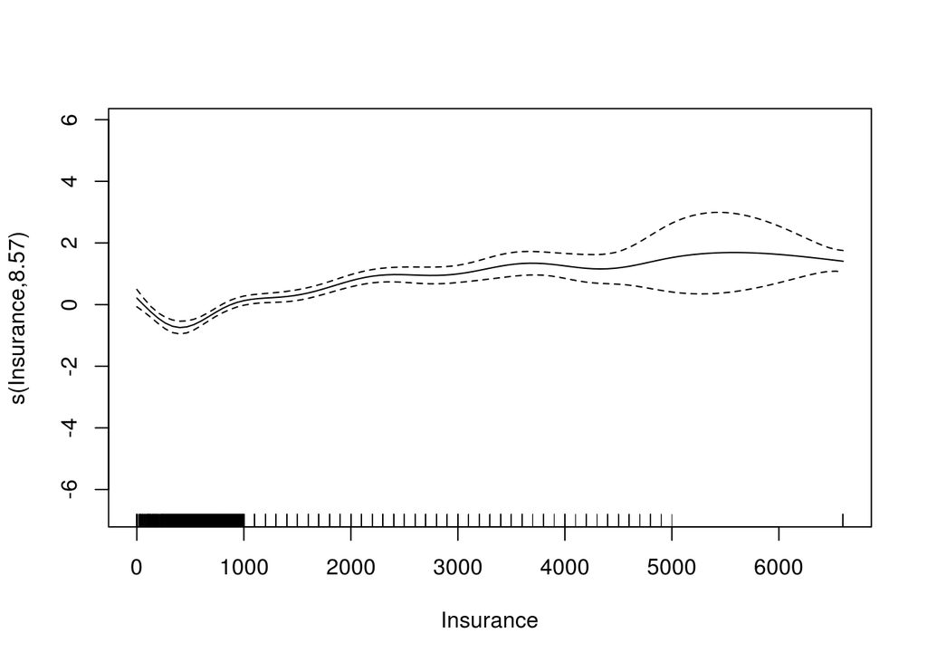

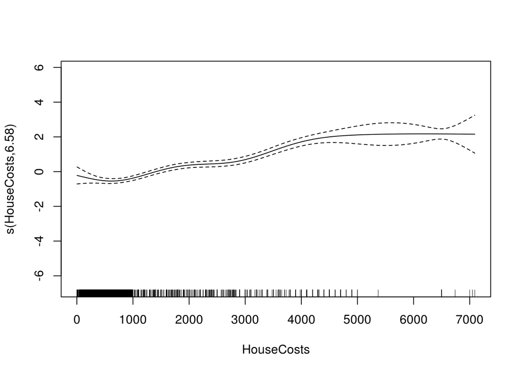

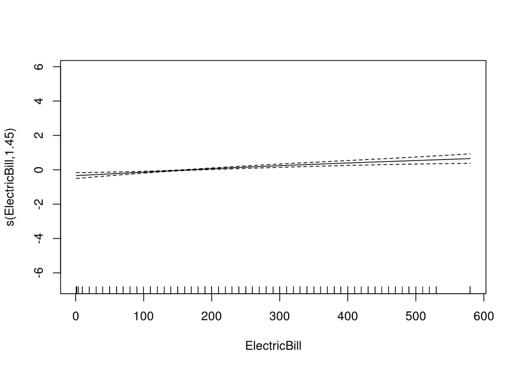

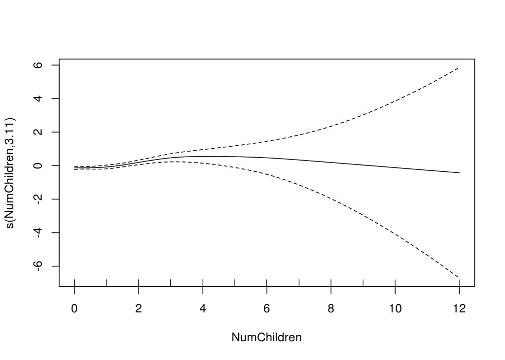

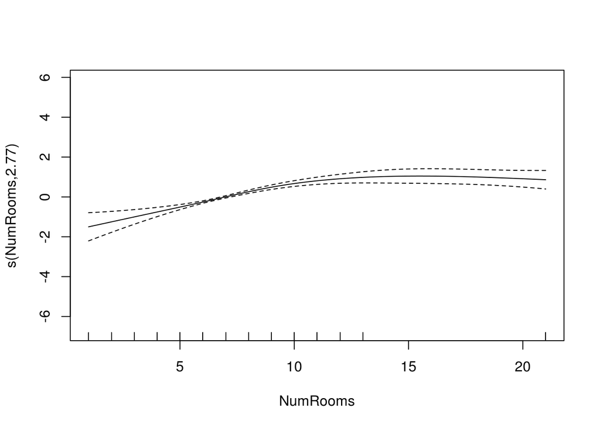

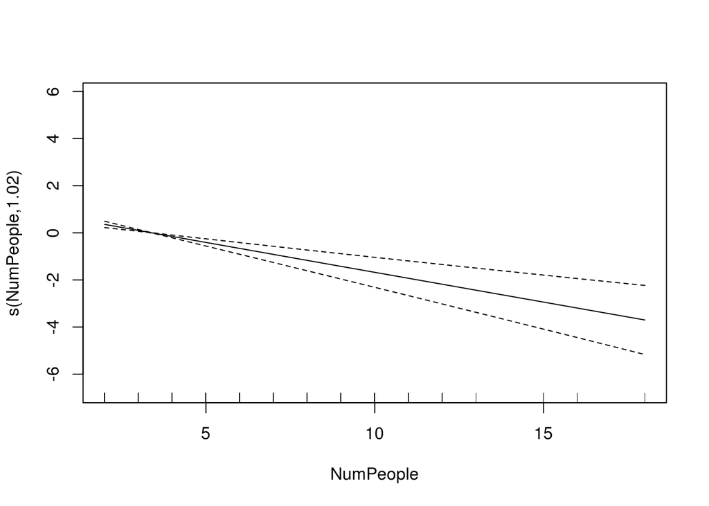

```r
plot(gam_mod2)
```

# MuMIn and the wonders of the dredge() function!

This package automates the model specification process to some degree. It does so by “dredging” through all possible combinations of independent variables. You can then display “best models” and importance metrics, which can then be used to specify your model.

https://sites.google.com/site/rforfishandwildlifegrads/home/mumin_usage_examples

1. Specify Model
2. Dredge
3. Model Summary
4. Find best models
5. Calculate importance weights

## GLM dredge

```r
# be aware that this takes time to run. It is worth the wait BUT frowned upon when used due to spurious results and inference
dredge_glm_mod <- glm(HighIncome ~ Insurance + HouseCosts + ElectricBill + FamilyType + FoodStamp + OwnRent +
              NumBedrooms + NumRooms, family=binomial(logit), na.action = "na.fail", data=acs_fit)

dd_glm <- dredge(dredge_glm_mod)
```

```
## Fixed term is "(Intercept)"
```

```r
summary(dredge_glm_mod)
```

```
##
## Call:
## glm(formula = HighIncome ~ Insurance + HouseCosts + ElectricBill +
##     FamilyType + FoodStamp + OwnRent + NumBedrooms + NumRooms,
##     family = binomial(logit), data = acs_fit, na.action = "na.fail")
##
## Deviance Residuals:
##     Min       1Q   Median       3Q      Max
## -2.6709  -0.3183  -0.2205  -0.1516   3.8289
##
## Coefficients:
##                       Estimate Std. Error z value Pr(>|z|)
## (Intercept)         -7.290e+00  2.415e-01 -30.179  < 2e-16 ***
## Insurance            3.115e-04  2.676e-05  11.637  < 2e-16 ***
## HouseCosts           5.372e-04  2.504e-05  21.455  < 2e-16 ***
## ElectricBill         2.099e-03  2.909e-04   7.215 5.39e-13 ***
## FamilyTypeMale Head  6.300e-01  3.220e-01   1.957  0.05036 .
## FamilyTypeMarried    1.578e+00  2.064e-01   7.647 2.06e-14 ***
## FoodStampYes        -1.682e+00  3.695e-01  -4.552 5.32e-06 ***
## OwnRentOutright      1.926e+00  3.133e-01   6.148 7.83e-10 ***
## OwnRentRented        7.924e-02  1.965e-01   0.403  0.68683
## NumBedrooms          8.726e-02  3.367e-02   2.591  0.00956 **
## NumRooms             1.131e-01  1.403e-02   8.060 7.62e-16 ***
## ---
## Signif. codes:  0 '***' 0.001 '**' 0.01 '*' 0.05 '.' 0.1 ' ' 1
##
## (Dispersion parameter for binomial family taken to be 1)
##
##     Null deviance: 8398.1  on 18195  degrees of freedom
## Residual deviance: 6265.0  on 18185  degrees of freedom
## AIC: 6287
##
## Number of Fisher Scoring iterations: 8
```

```r
# best supported models
subset(dd_glm, delta < 5)
```

```
## Global model call: glm(formula = HighIncome ~ Insurance + HouseCosts + ElectricBill +
##     FamilyType + FoodStamp + OwnRent + NumBedrooms + NumRooms,
##     family = binomial(logit), data = acs_fit, na.action = "na.fail")
## ---
## Model selection table
##     (Intrc)    ElctB FmlyT FdStm     HsCst     Insrn   NmBdr  NmRms OwnRn
## 256  -7.290 0.002099     +     + 0.0005372 0.0003114 0.08726 0.1131     +
## 224  -7.152 0.002180     +     + 0.0005430 0.0003188         0.1321     +
##     df    logLik   AICc delta weight
## 256 11 -3132.486 6287.0  0.00  0.908
## 224 10 -3135.771 6291.6  4.57  0.092
## Models ranked by AICc(x)
```

```r
# best model
subset(dd_glm, delta == 0)
```

```
## Global model call: glm(formula = HighIncome ~ Insurance + HouseCosts + ElectricBill +
##     FamilyType + FoodStamp + OwnRent + NumBedrooms + NumRooms,
##     family = binomial(logit), data = acs_fit, na.action = "na.fail")
## ---
## Model selection table
##     (Intrc)    ElctB FmlyT FdStm     HsCst     Insrn   NmBdr  NmRms OwnRn
## 256   -7.29 0.002099     +     + 0.0005372 0.0003114 0.08726 0.1131     +
##     df    logLik AICc delta weight
## 256 11 -3132.486 6287     0      1
## Models ranked by AICc(x)
```

#### LM dredge

```r
dredge_lm_mod <- lm(HighIncome ~ FamilyType + HouseCosts + Insurance + NumRooms + ElectricBill + FoodStamp +
                      OwnRent + NumBedrooms, data = acs_fit, na.action = na.fail)

dd_lm <- dredge(dredge_lm_mod)
```

```
## Fixed term is "(Intercept)"
```

```r
summary(dredge_lm_mod)
```

```
##
## Call:
## lm(formula = HighIncome ~ FamilyType + HouseCosts + Insurance +
##     NumRooms + ElectricBill + FoodStamp + OwnRent + NumBedrooms,
##     data = acs_fit, na.action = na.fail)
##
## Residuals:
##      Min       1Q   Median       3Q      Max
## -0.69682 -0.08760 -0.02763  0.01461  1.06314
##
## Coefficients:
##                       Estimate Std. Error t value Pr(>|t|)
## (Intercept)         -1.760e-01  7.444e-03 -23.639  < 2e-16 ***
## FamilyTypeMale Head  8.939e-03  8.467e-03   1.056   0.2911
## FamilyTypeMarried    3.353e-02  4.889e-03   6.858 7.19e-12 ***
## HouseCosts           4.880e-05  1.695e-06  28.791  < 2e-16 ***
## Insurance            4.178e-05  2.004e-06  20.845  < 2e-16 ***
## NumRooms             9.480e-03  8.948e-04  10.594  < 2e-16 ***
## ElectricBill         9.443e-05  1.662e-05   5.682 1.35e-08 ***
## FoodStampYes        -1.475e-02  6.523e-03  -2.261   0.0238 *
## OwnRentOutright      1.269e-01  1.957e-02   6.481 9.31e-11 ***
## OwnRentRented        4.821e-02  5.871e-03   8.211 2.34e-16 ***
## NumBedrooms          2.370e-03  1.948e-03   1.217   0.2237
## ---
## Signif. codes:  0 '***' 0.001 '**' 0.01 '*' 0.05 '.' 0.1 ' ' 1
##
## Residual standard error: 0.2191 on 18185 degrees of freedom
## Multiple R-squared:  0.1671, Adjusted R-squared:  0.1667
## F-statistic: 364.9 on 10 and 18185 DF,  p-value: < 2.2e-16
```

```r
subset(dd_lm, delta < 5)
```

```
## Global model call: lm(formula = HighIncome ~ FamilyType + HouseCosts + Insurance +
##     NumRooms + ElectricBill + FoodStamp + OwnRent + NumBedrooms,
##     data = acs_fit, na.action = na.fail)
## ---
## Model selection table
##     (Intrc)     ElctB FmlyT FdStm     HsCst     Insrn    NmBdr    NmRms
## 224 -0.1731 9.647e-05     +     + 4.896e-05 4.194e-05          0.010110
## 256 -0.1760 9.443e-05     +     + 4.880e-05 4.178e-05 0.002370 0.009480
## 220 -0.1756 9.499e-05     +       4.922e-05 4.193e-05          0.010110
## 252 -0.1782 9.317e-05     +       4.908e-05 4.179e-05 0.002055 0.009564
##     OwnRn df   logLik    AICc delta weight
## 224     + 11 1809.015 -3596.0  0.00  0.457
## 256     + 12 1809.756 -3595.5  0.52  0.352
## 220     + 10 1806.639 -3593.3  2.75  0.116
## 252     + 11 1807.199 -3592.4  3.63  0.074
## Models ranked by AICc(x)
```

```r
subset(dd_lm, delta == 0)
```

```
## Global model call: lm(formula = HighIncome ~ FamilyType + HouseCosts + Insurance +
##     NumRooms + ElectricBill + FoodStamp + OwnRent + NumBedrooms,
##     data = acs_fit, na.action = na.fail)
## ---
## Model selection table
##     (Intrc)     ElctB FmlyT FdStm     HsCst     Insrn   NmRms OwnRn df
## 224 -0.1731 9.647e-05     +     + 4.896e-05 4.194e-05 0.01011     + 11
##       logLik  AICc delta weight
## 224 1809.015 -3596     0      1
## Models ranked by AICc(x)
```

# Regression Model Comparison

List of all regression models

```r
sprintf("LOGISTIC REGRESSION")
```

```
## [1] "LOGISTIC REGRESSION"
```

```r
sprintf("Logistic model 1: Predicted Accuracy = %.4f Predicted Sensitivity = %.3f AIC = %.1f",
        log_cm1$overall['Accuracy'], log_cm1$byClass['Sensitivity'], log_mod1_aic)
```

```
## [1] "Logistic model 1: Predicted Accuracy = 0.6324 Predicted Sensitivity = 0.790 AIC = 7118.0"
```

```r
sprintf("Logistic model 2: Predicted Accuracy = %.4f Predicted Sensitivity = %.3f AIC = %.1f",
        log_cm2$overall['Accuracy'], log_cm2$byClass['Sensitivity'], log_mod2_aic)
```

```
## [1] "Logistic model 2: Predicted Accuracy = 0.3317 Predicted Sensitivity = 0.897 AIC = 8049.1"
```

```r
sprintf("Logistic model 3: Predicted Accuracy = %.4f Predicted Sensitivity = %.3f AIC = %.1f",
        log_cm3$overall['Accuracy'], log_cm3$byClass['Sensitivity'], log_mod3_aic)
```

```
## [1] "Logistic model 3: Predicted Accuracy = 0.7232 Predicted Sensitivity = 0.735 AIC = 7319.5"
```

```r
sprintf("Logistic model 4: Predicted Accuracy = %.4f Predicted Sensitivity = %.3f AIC = %.1f",
        log_cm4$overall['Accuracy'], log_cm4$byClass['Sensitivity'], log_mod4_aic)
```

```
## [1] "Logistic model 4: Predicted Accuracy = 0.7191 Predicted Sensitivity = 0.732 AIC = 7412.8"
```

```r
sprintf("Logistic model 5: Predicted Accuracy = %.4f Predicted Sensitivity = %.3f AIC = %.1f",
        log_cm5$overall['Accuracy'], log_cm5$byClass['Sensitivity'], log_mod5_aic)
```

```
## [1] "Logistic model 5: Predicted Accuracy = 0.7402 Predicted Sensitivity = 0.816 AIC = 6188.7"
```

```r
sprintf("Logistic model 6: Predicted Accuracy = %.4f Predicted Sensitivity = %.3f AIC = %.1f",
        log_cm6$overall['Accuracy'], log_cm6$byClass['Sensitivity'], log_mod6_aic)
```

```
## [1] "Logistic model 6: Predicted Accuracy = 0.7270 Predicted Sensitivity = 0.798 AIC = 6374.8"
```

```r
sprintf("Logistic model 6: Predicted Accuracy = %.4f Predicted Sensitivity = %.3f AIC = %.1f",
        log_cm6$overall['Accuracy'], log_cm6$byClass['Sensitivity'], log_mod6_aic)
```

```
## [1] "Logistic model 6: Predicted Accuracy = 0.7270 Predicted Sensitivity = 0.798 AIC = 6374.8"
```

```r
sprintf("                                                                                        ")
```

```
## [1] "                                                                                        "
```

```r
sprintf("LINEAR REGRESSION")
```

```
## [1] "LINEAR REGRESSION"
```

```r
sprintf("Linear model 1:   Predicted Accuracy = %.4f Predicted Sensitivity = %.3f Adj R-squared = %.3f",
        linear_cm1$overall['Accuracy'], linear_cm1$byClass['Sensitivity'], linear_mod1_rsq)
```

```
## [1] "Linear model 1:   Predicted Accuracy = 0.9444 Predicted Sensitivity = 0.243 Adj R-squared = 0.314"
```

```r
sprintf("Linear model 2:   Predicted Accuracy = %.4f Predicted Sensitivity = %.3f Adj R-squared = %.3f",
        linear_cm2$overall['Accuracy'], linear_cm2$byClass['Sensitivity'], linear_mod2_rsq)
```

```
## [1] "Linear model 2:   Predicted Accuracy = 0.9435 Predicted Sensitivity = 0.239 Adj R-squared = 0.341"
```

```r
sprintf("                                                                                        ")
```

```
## [1] "                                                                                        "
```

```r
sprintf("SUPPORT VECTOR MACHINES")
```

```
## [1] "SUPPORT VECTOR MACHINES"
```

```r
sprintf("SVM model 1:      Predicted Accuracy = %.4f Predicted Sensitivity = %.3f",
        svm_cm1$overall['Accuracy'], svm_cm1$byClass['Sensitivity'])
```

```
## [1] "SVM model 1:      Predicted Accuracy = 0.9453 Predicted Sensitivity = 0.151"
```

```r
sprintf("SVM model 2:      Predicted Accuracy = %.4f Predicted Sensitivity = %.3f",
        svm_cm2$overall['Accuracy'], svm_cm2$byClass['Sensitivity'])
```

```
## [1] "SVM model 2:      Predicted Accuracy = 0.9455 Predicted Sensitivity = 0.180"
```

```r
sprintf("SVM model 3:      Predicted Accuracy = %.4f Predicted Sensitivity = %.3f",
        svm_cm3$overall['Accuracy'], svm_cm3$byClass['Sensitivity'])
```

```
## [1] "SVM model 3:      Predicted Accuracy = 0.9466 Predicted Sensitivity = 0.176"
```

```r
sprintf("                                                                                        ")
```

```
## [1] "                                                                                        "
```

```r
sprintf("MULTILEVEL MODEL SPECIFICATION")
```

```
## [1] "MULTILEVEL MODEL SPECIFICATION"
```

```r
sprintf("MMS model 1:      Predicted Accuracy = NA    Predicted Sensitivity = NA    AIC = %.1f", mms1_aic)
```

```
## [1] "MMS model 1:      Predicted Accuracy = NA    Predicted Sensitivity = NA    AIC = -3398.4"
```

```r
sprintf("MMS model 2:      Predicted Accuracy = NA    Predicted Sensitivity = NA    AIC = %.1f", mms2_aic)
```

```
## [1] "MMS model 2:      Predicted Accuracy = NA    Predicted Sensitivity = NA    AIC = -462.3"
```

```r
sprintf("                                                                                        ")
```

```
## [1] "                                                                                        "
```

```r
sprintf("GENERALIZED ADDITIVE MODELS")
```

```
## [1] "GENERALIZED ADDITIVE MODELS"
```

```r
sprintf("GAM model 1:      Predicted Accuracy = %.4f Predicted Sensitivity = %.3f AIC = %.1f",
        gam_cm1$overall['Accuracy'], gam_cm1$byClass['Sensitivity'], gam_mod_aic)
```

```
## [1] "GAM model 1:      Predicted Accuracy = 0.9398 Predicted Sensitivity = 0.243 AIC = 463153.9"
```

```r
sprintf("GAM model 2:      Predicted Accuracy = %.4f Predicted Sensitivity = %.3f AIC = %.1f",
        gam_cm2$overall['Accuracy'], gam_cm2$byClass['Sensitivity'], gam_mod2_aic)
```

```
## [1] "GAM model 2:      Predicted Accuracy = 0.9435 Predicted Sensitivity = 0.121 AIC = 6075.4"
```

# Regression model decision & comments